# Evidencia 2 | Proyecto integrador

Escuela: Tecnologico de Monterrey

Materia: Análisis de biología computacional (Gpo 513)

Alumno: Renet de Jesús Pérez Gómez

Codigo: A01640555

Parte 1 - Video 1

Liga directa a video

https://drive.google.com/file/d/1oUbun_TX_2tx70kU5VgJl-q00z5WaCOD/view?usp=sharing

Parte 2 - Video 2

Exportamos librerias

```r
library(seqinr)
```

```r
library(ggplot2)
library(ggthemes)
library(Biostrings)
library(adegenet)
library(ape)
library(ggtree)
library(DECIPHER)
library(viridis)
```

Indicaciones 1-Analizar las secuencias de SARS-CoV-2 reportadas en los 20 países con más casos reportados. Y puedes tratar de responder a la pregunta: ¿Son muy diferentes las variantes entre cada país? ¿Es diferente el SARS-CoV-2 entre las diferentes poblaciones: Asiática, Hispana, Europea o Africana?

Exportamos datos

```r
setwd("C:/Users/RENET/Documents/TEC DE MONTERREY/Semestre 2/Modulo 2/Biologia computacional/entregable_2/variantes");
cov_USA<-read.fasta("1sequence USA.fasta");
cov_IND<-read.fasta("2sequenceIND.fasta");
cov_BRA<-read.fasta("3sequenceBRA.fasta");
cov_FRA<-read.fasta("4sequenceFRA.fasta");
cov_RUS<-read.fasta("5sequenceRUS.fasta");
cov_TUR<-read.fasta("6sequenceTUR.fasta");
cov_END<-read.fasta("7sequence END.fasta");
cov_ITA<-read.fasta("8sequence ITA.fasta");
cov_ESP<-read.fasta("9sequenceESP.fasta");
cov_DEU<-read.fasta("10sequenceDEU.fasta");
cov_ARG<-read.fasta("11sequenceARG.fasta");
cov_POLEN<-read.fasta("12sequencePOLEN.fasta");
cov_COL<-read.fasta("13sequenceCOL.fasta");
cov_IRN<-read.fasta("14sequenceIRN.fasta");
cov_MEX<-read.fasta("15sequenceMEX.fasta");
cov_PER<-read.fasta("16sequencePER.fasta");
cov_CZE<-read.fasta("17sequenceCZE.fasta");
cov_ZFA<-read.fasta("18sequenceZFA.fasta");
cov_NLD<-read.fasta("19sequenceNLD.fasta");
cov_CHL<-read.fasta("20sequenceCHL.fasta");
```

2-Calcula la longitud de las secuencias que incluyas.

```r
#Calculamos longitud de cada cepa
l_cov_USA <- length(cov_USA[[1]])
l_cov_IND <- length(cov_IND[[1]])
l_cov_BRA <- length(cov_BRA[[1]])
l_cov_FRA <- length(cov_FRA[[1]])
l_cov_RUS <- length(cov_RUS[[1]])
l_cov_TUR <- length(cov_TUR[[1]])
l_cov_END <- length(cov_END[[1]])
l_cov_ITA <- length(cov_ITA[[1]])
l_cov_ESP <- length(cov_ESP[[1]])
l_cov_DEU <- length(cov_DEU[[1]])
l_cov_ARG <- length(cov_ARG[[1]])
l_cov_POLEN <- length(cov_POLEN[[1]])
l_cov_COL <- length(cov_COL[[1]])
l_cov_IRN <- length(cov_IRN[[1]])
l_cov_MEX <- length(cov_MEX[[1]])
l_cov_PER <- length(cov_PER[[1]])
l_cov_CZE <- length(cov_CZE[[1]])
l_cov_ZFA <- length(cov_ZFA[[1]])
l_cov_NLD <- length(cov_NLD[[1]])
l_cov_CHL <- length(cov_CHL[[1]])

L<-"Longitudes de las secuencias"
A<-"(Ordenado del pais mas infectado al menos infectado)"
tablaInfoLong <- data.frame(Pais=rep(c('USA','IND','BRA','FRA','RUS',
                                       'TUR','END','ITA','ESP','DEU',
                                       'ARG','POL','COL','IRN','MEX',
                                       'PER','CZE','ZFA','NLD','CHL')),
                            Longuitud=rep(c(as.vector(l_cov_USA),
                                            as.vector(l_cov_IND),
                                            as.vector(l_cov_BRA),
                                            as.vector(l_cov_FRA),
                                            as.vector(l_cov_RUS),
                                            as.vector(l_cov_TUR),
                                            as.vector(l_cov_END),
                                            as.vector(l_cov_ITA),
                                            as.vector(l_cov_ESP),
                                            as.vector(l_cov_DEU),
                                            as.vector(l_cov_ARG),
                                            as.vector(l_cov_POLEN),
                                            as.vector(l_cov_COL),
                                            as.vector(l_cov_IRN),
                                            as.vector(l_cov_MEX),
                                            as.vector(l_cov_PER),
                                            as.vector(l_cov_CZE),
                                            as.vector(l_cov_ZFA),
                                            as.vector(l_cov_NLD),
                                            as.vector(l_cov_CHL)
                                            )))
L
```

```
## [1] "Longitudes de las secuencias"
```

```r
A
```

```
## [1] "(Ordenado del pais mas infectado al menos infectado)"
```

```r
tablaInfoLong
```

```
##    Pais Longuitud
## 1   USA     29763
## 2   IND     29866
## 3   BRA     29837
## 4   FRA     29903
## 5   RUS     29826
## 6   TUR     29867
## 7   END     29846
## 8   ITA     29834
## 9   ESP     29763
## 10  DEU     29782
## 11  ARG     29721
## 12  POL     29897
## 13  COL     29903
## 14  IRN     29819
## 15  MEX     29855
## 16  PER     29856
## 17  CZE     29871
## 18  ZFA     29903
## 19  NLD     29833
## 20  CHL     29409
```

3-Crea una sola gráfica donde se comparen el número de bases de ADN que componen todas las variantes del virus.

```r
numBases <- 4
#Creamos conjuntos
datos1 <- data.frame( bases=rep(c('A', 'C', 'G', 'T'), times=6),
virus=c(rep("USA", times=numBases),
        rep("IND", times=numBases),
        rep("BRA", times=numBases),
        rep("FRA", times=numBases),
        rep("RUS", times=numBases),
        rep("TUR", times=numBases)
        ),
tots=c(as.vector(table(cov_USA)),
       as.vector(table(cov_IND)),
       as.vector(table(cov_BRA)),
       as.vector(table(cov_FRA)),
       as.vector(table(cov_RUS)),
       as.vector(table(cov_TUR))
       ));
head(datos1)
```

```
##   bases virus tots
## 1     A   USA 8890
## 2     C   USA 5458
## 3     G   USA 5843
## 4     T   USA 9572
## 5     A   IND 8922
## 6     C   IND 5487
```

```r
str(datos1)
```

```
## 'data.frame':    24 obs. of  3 variables:
##  $ bases: chr  "A" "C" "G" "T" ...
##  $ virus: chr  "USA" "USA" "USA" "USA" ...
##  $ tots : int  8890 5458 5843 9572 8922 5487 5859 9598 8909 5484 ...
```

```r
datos2 <- data.frame( bases=rep(c('A', 'C', 'G', 'T'), times=6),
virus=c(rep("END", times=numBases),
        rep("ITA", times=numBases),
        rep("ESP", times=numBases),
        rep("DEU", times=numBases),
        rep("ARG", times=numBases),
        rep("POL", times=numBases)
        ),
tots=c(as.vector(table(cov_END)),
       as.vector(table(cov_ITA)),
       as.vector(table(cov_ESP)),
       as.vector(table(cov_DEU)),
       as.vector(table(cov_ARG)),
       as.vector(table(cov_POLEN))
       ));
head(datos2)
```

```
##   bases virus tots
## 1     A   END 8919
## 2     C   END 5486
## 3     G   END 5856
## 4     T   END 9585
## 5     A   ITA 8909
## 6     C   ITA 5473
```

```r
str(datos2)
```

```
## 'data.frame':    24 obs. of  3 variables:
##  $ bases: chr  "A" "C" "G" "T" ...
##  $ virus: chr  "END" "END" "END" "END" ...
##  $ tots : int  8919 5486 5856 9585 8909 5473 5855 9597 8892 5460 ...
```

```r
datos3 <- data.frame( bases=rep(c('A', 'C', 'G', 'T'), times=8),
virus=c(rep("COL", times=numBases),
        rep("IRN", times=numBases),
        rep("MEX", times=numBases),
        rep("PER", times=numBases),
        rep("CZE", times=numBases),
        rep("ZFA", times=numBases),
        rep("NLD", times=numBases),
        rep("CHL", times=numBases)
        ),
tots=c(as.vector(table(cov_COL)),
       as.vector(table(cov_IRN)),
       as.vector(table(cov_MEX)),
       as.vector(table(cov_PER)),
       as.vector(table(cov_CZE)),
       as.vector(table(cov_ZFA)),
       as.vector(table(cov_NLD)),
       as.vector(table(cov_CHL))
       ));
head(datos3)
```

```
##   bases virus tots
## 1     A   COL 8952
## 2     C   COL 5488
## 3     G   COL 5863
## 4     T   COL 9600
## 5     A   IRN 8907
## 6     C   IRN 5481
```

```r
str(datos3)
```

```
## 'data.frame':    32 obs. of  3 variables:
##  $ bases: chr  "A" "C" "G" "T" ...
##  $ virus: chr  "COL" "COL" "COL" "COL" ...
##  $ tots : int  8952 5488 5863 9600 8907 5481 5851 9580 8910 5486 ...
```

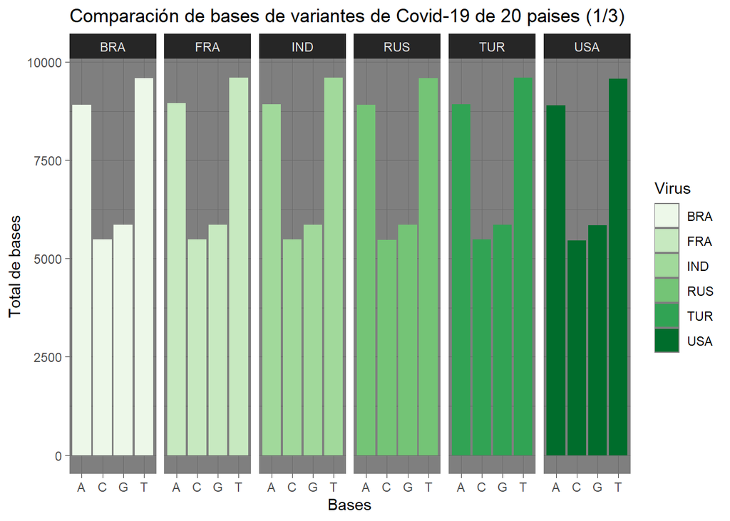

```r
#Graficamos
p1 <- ggplot(datos1, aes(x=bases, y=tots, fill=virus)) + geom_bar(stat = "identity")  + facet_grid(~virus) + scale_fill_brewer(palette = "Greens") + ggtitle("Comparación de bases de variantes de Covid-19 de 20 paises (1/3)") + labs(x="Bases", y="Total de bases", fill="Virus") + theme_dark()

p2 <- ggplot(datos2, aes(x=bases, y=tots, fill=virus)) + geom_bar(stat = "identity")  + facet_grid(~virus) + scale_fill_brewer(palette = "Blues") + ggtitle("Comparación de bases de variantes de Covid-19 de 20 paises (2/3)") + labs(x="Bases", y="Total de bases", fill="Virus") + theme_dark()

p3 <- ggplot(datos3, aes(x=bases, y=tots, fill=virus)) + geom_bar(stat = "identity")  + facet_grid(~virus) + scale_fill_brewer(palette = "Oranges") + ggtitle("Comparación de bases de variantes de Covid-19 de 20 paises (3/3)") + labs(x="Bases", y="Total de bases", fill="Virus") + theme_dark()

#Imprimimos graficas
p1
```

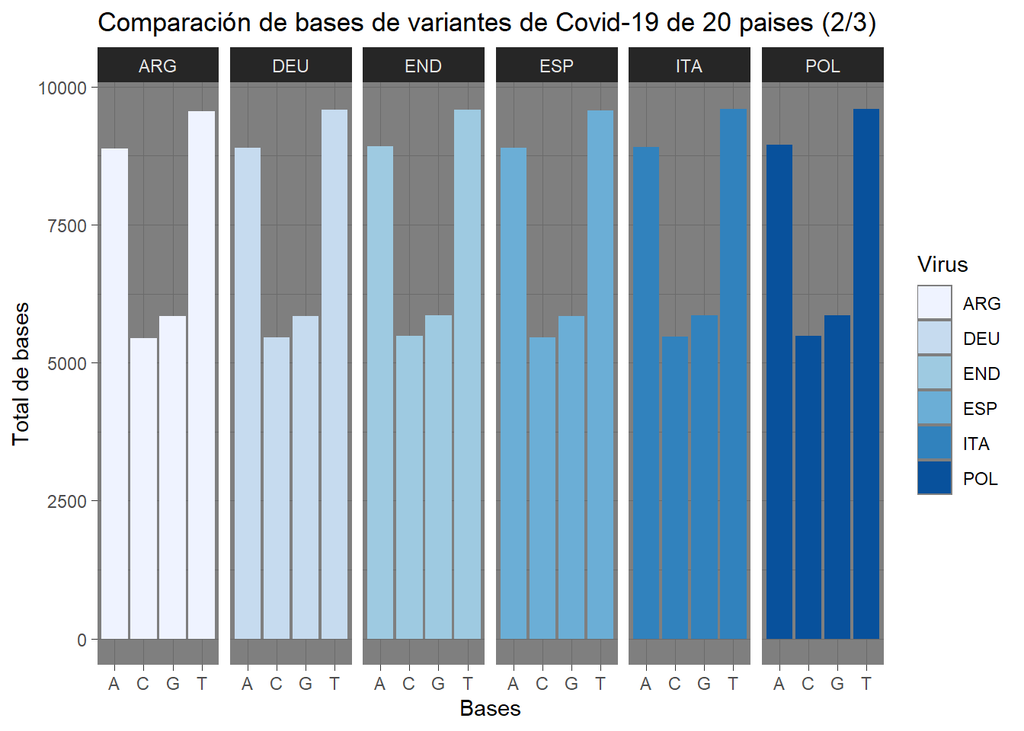

```r
p2
```

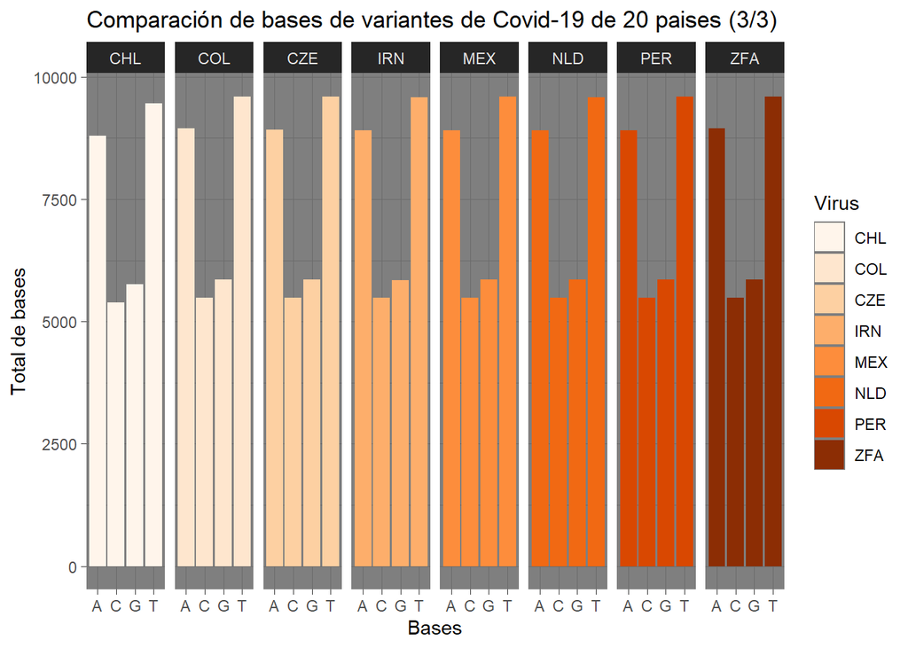

```r
p3
```

4-Agrega un análisis jerárquico global obtenido de las secuencias que se seleccionaron para estudiar.

```r
#Creamos un vector con todas las variantes de coronavirus
varaintes_covid <- c("MW989374","MT416726","MT844030","MW322968","MW332241",
                     "MW306667","MW059036","MW789246","MW976781","MW822593",
                     "MW633908","MT511082","MT470219","MT994881","MW595908",
                     "MT263074","MT517433","MT324062","MW577029","MW064264")

#Solicitamos a la base de datos
variantes_secuencias <- read.GenBank(varaintes_covid)

#Concatenamos en un mismo archivo todas las secuencias y guardamos en un ".fasta"
write.dna(variantes_secuencias,  file ="covid-variantes.fasta", format = "fasta",
          append = FALSE, nbcol = 6, colsep = " ", colw = 10)

#Recuperamos la informacion del ".fasta" que creamos
varaintes_secuencias_no_alineadas <- readDNAStringSet("covid-variantes.fasta",
                                                      format = "fasta")
#Comenzamos proceso de alineacion de secuencias
varaintes_secuencias_no_alineadas <- OrientNucleotides(varaintes_secuencias_no_alineadas)
```

```
## ========================================================================================================================================================================================================
##
## Time difference of 0.32 secs
```

```r
varaintes_secuencias_alineadas <- AlignSeqs(varaintes_secuencias_no_alineadas)
```

[output not shown]

```r
BrowseSeqs(varaintes_secuencias_alineadas, highlight=0)

#Guradamos el resultado de aliniacion en un ".fasta."
writeXStringSet(varaintes_secuencias_alineadas, file="variantes_secuencias_alineadas.fasta")

#Extraemos
varaintes_secuencias_alineadas <- read.alignment("variantes_secuencias_alineadas.fasta", format = "fasta")

#Creamos una matriz de distancia, la cual nos ayudara a hacer el arbol
matriz_distancia <- dist.alignment(varaintes_secuencias_alineadas, matrix = "similarity")

#Creamos arbol
virus_tree <- nj(matriz_distancia)
class(virus_tree)
```

```
## [1] "phylo"
```

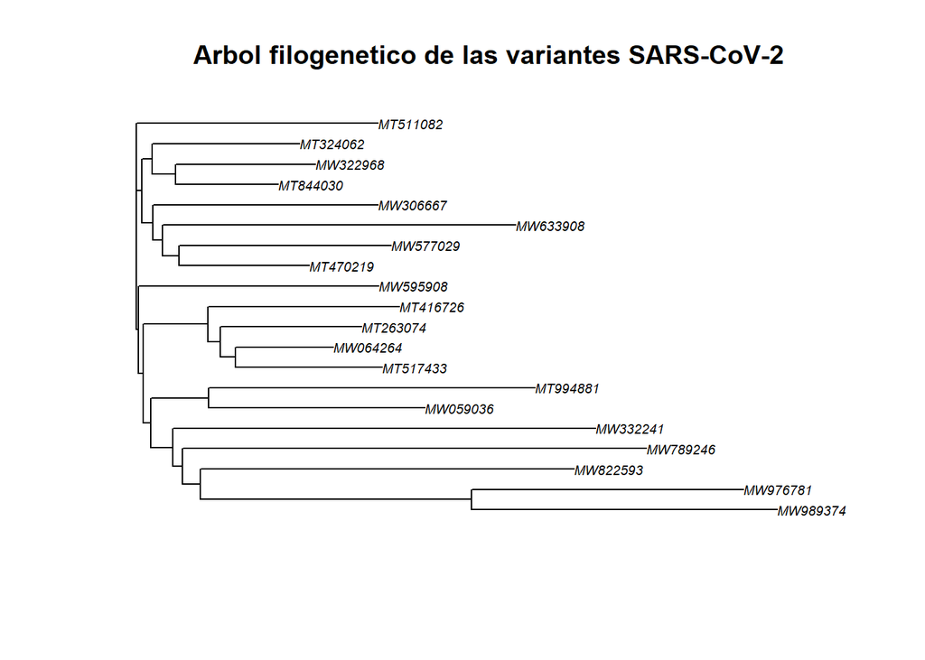

```r
virus_tree <- ladderize(virus_tree)

#Graficamos arbol
plot(virus_tree, cex = 0.6)
title("Arbol filogenetico de las variantes SARS-CoV-2")
```

```r
L<-"Variante que pertenece a:"
A<-"(Ordenado del pais mas infectado al menos infectado)"
tablaInfo <- data.frame(
      Pais=rep(c('USA','IND','BRA','FRA','RUS',
                 'TUR','END','ITA','ESP','DEU',
                 'ARG','POL','COL','IRN','MEX',
                 'PER','CZE','ZFA','NLD','CHL')),
      Variante=rep(c("MW989374","MT416726","MT844030","MW322968","MW332241",
                     "MW306667","MW059036","MW789246","MW976781","MW822593",
                     "MW633908","MT511082","MT470219","MT994881","MW595908",
                     "MT263074","MT517433","MT324062","MW577029","MW064264")))
L
```

```
## [1] "Variante que pertenece a:"
```

```r
A
```

```
## [1] "(Ordenado del pais mas infectado al menos infectado)"
```

```r
tablaInfo
```

```
##    Pais Variante
## 1   USA MW989374
## 2   IND MT416726
## 3   BRA MT844030
## 4   FRA MW322968
## 5   RUS MW332241
## 6   TUR MW306667
## 7   END MW059036
## 8   ITA MW789246
## 9   ESP MW976781
## 10  DEU MW822593
## 11  ARG MW633908
## 12  POL MT511082
## 13  COL MT470219
## 14  IRN MT994881
## 15  MEX MW595908
## 16  PER MT263074
## 17  CZE MT517433
## 18  ZFA MT324062
## 19  NLD MW577029
## 20  CHL MW064264
```

```r
at <-c('USA','IND','BRA','FRA','RUS',
                 'TUR','END','ITA','ESP','DEU',
                 'ARG','POL','COL','IRN','MEX',
                 'PER','CZE','ZFA','NLD','CHL')
at2 <- c("MW989374","MT416726","MT844030","MW322968","MW332241",
                     "MW306667","MW059036","MW789246","MW976781","MW822593",
                     "MW633908","MT511082","MT470219","MT994881","MW595908",
                     "MT263074","MT517433","MT324062","MW577029","MW064264")
```

5-Agrega una interpretación escrita de tus gráficas y tus conclusiones según el caso de estudio que seleccionaste.

-Intepretación y conlución de las graficas- Podemos analizar en el grafico de barras que las variantes del coronavirus no varian mucho a nivel genomico, graficamente podemos ver que son practicamete lo mismo, sin embargo, esto nos puede ayudar a corroborar que todas las secuencias analizadas se tratan de la misma especie.

Donde se logra ver la diferencia entre las variantes de Covid-19 es en el arbol filogenetico, es lógico que mute en los diferentes paises ya que presentan diferentes condiciones para el virus, sumado a que por su “relativa” simplicidad genomica lo hace muy supsetible a mutaciones, esto puede explicar su gran cantidad de variación en tan poco tiempo.

Hay dos casos particulares que se me hacen bastante interesantes, el primero es con la variante MW989374 de USA, principalmente a que a pesar de ser un pais tan importante, existe una variante tan distante a otras, aunque se puede explicar esto ya lleva tiempo siendo el foco de la enfermedad.

En segundo lugar esta el caso de México, con la variante MW595908, a pesar de ser bastante un pais vecino del foco de la enfermedad hay muchisima diferencia con esta, y que de hecho es una con una taxonomia bastante independiente al resto de las cepas, realmente no me explico el porque de esta situación.

En conclución, puedo decir que esta clase de analisis es bastante importante ya que nos ayudan a comprender la naturaleza de la enfermedad, y el peligro que puede suponer la alta tasa de mutabilidad del virus, citando.

Arguemntando el planteamiento anterior, cito textualmente el siguiente articulo: “Se sabe que incluso mutaciones únicas en proteínas específicas pueden cambiar la patogenicidad de estos virus” (Bianchi, M., Borsetti, A., Ciccozzi, M., & Pascarella, S. (2021), introducción-parrafo 2, https://doi.org/10.1016/j.ijbiomac.2020.12.142).

Recuperando el segundo caso que expuse, si el virus se aleja bastante de la familia principal puede suponer un gran problema para mexico ya que aumenta la posibilidad que cuando salga una futura vacuna, esta no sea efectiva.

Es por ello que cobra mucho sentido las medidas preventivas ya que mientras mas expandida este la enfermedad mas posibilidades hay de que esta se vuelva mas compleja de resolver (hablando desde todos los puntos de vista, desde los economico y sociales, hasta los biologicos).

Bibliografía

```r
#Librerias utilizadas para hacer el proyecto:

citation( package =  "seqinr")
```

```
##
##
##   Charif, D. and Lobry, J.R. (2007)
##
## A BibTeX entry for LaTeX users is
##
##   @InCollection{,
##     author = {D. Charif and J.R. Lobry},
##     title = {Seqin{R} 1.0-2: a contributed package to the {R} project for statistical computing devoted to biological sequences retrieval and analysis.},
##     booktitle = {Structural approaches to sequence evolution: Molecules, networks, populations},
##     year = {2007},
##     editor = {U. Bastolla and M. Porto and H.E. Roman and M. Vendruscolo},
##     series = {Biological and Medical Physics, Biomedical Engineering},
##     pages = {207-232},
##     address = {New York},
##     publisher = {Springer Verlag},
##     note = {{ISBN :} 978-3-540-35305-8},
##   }
```

```r
citation( package =  "ggplot2")
```

```
##
##
##   H. Wickham. ggplot2: Elegant Graphics for Data Analysis.
##   Springer-Verlag New York, 2016.
##
## A BibTeX entry for LaTeX users is
##
##   @Book{,
##     author = {Hadley Wickham},
##     title = {ggplot2: Elegant Graphics for Data Analysis},
##     publisher = {Springer-Verlag New York},
##     year = {2016},
##     isbn = {978-3-319-24277-4},
##     url = {https://ggplot2.tidyverse.org},
##   }
```

```r
citation( package =  "ggthemes")
```

```
##
##
##   Jeffrey B. Arnold (2021). ggthemes: Extra Themes, Scales and Geoms
##   for 'ggplot2'. R package version 4.2.4.
##   https://CRAN.R-project.org/package=ggthemes
##
## A BibTeX entry for LaTeX users is
##
##   @Manual{,
##     title = {ggthemes: Extra Themes, Scales and Geoms for 'ggplot2'},
##     author = {Jeffrey B. Arnold},
##     year = {2021},
##     note = {R package version 4.2.4},
##     url = {https://CRAN.R-project.org/package=ggthemes},
##   }
```

```r
citation( package =  "Biostrings")
```

```
##
##
##   H. Pagès, P. Aboyoun, R. Gentleman and S. DebRoy (2020). Biostrings:
##   Efficient manipulation of biological strings. R package version
##   2.58.0. https://bioconductor.org/packages/Biostrings
##
## A BibTeX entry for LaTeX users is
##
##   @Manual{,
##     title = {Biostrings: Efficient manipulation of biological strings},
##     author = {H. Pagès and P. Aboyoun and R. Gentleman and S. DebRoy},
##     year = {2020},
##     note = {R package version 2.58.0},
##     url = {https://bioconductor.org/packages/Biostrings},
##   }
##
## ATTENTION: This citation information has been auto-generated from the
## package DESCRIPTION file and may need manual editing, see
## 'help("citation")'.
```

```r
citation( package =  "adegenet")
```

```
##
##
##   Jombart, T. (2008) adegenet: a R package for the multivariate
##   analysis of genetic markers. Bioinformatics 24: 1403-1405. doi:
##   10.1093/bioinformatics/btn129
##
##   Jombart T. and Ahmed I. (2011) adegenet 1.3-1: new tools for the
##   analysis of genome-wide SNP data. Bioinformatics. doi:
##   10.1093/bioinformatics/btr521
##
## To see these entries in BibTeX format, use 'print(<citation>,
## bibtex=TRUE)', 'toBibtex(.)', or set
## 'options(citation.bibtex.max=999)'.
```

```r
citation( package =  "ape")
```

```
##
##
##   Paradis E. & Schliep K. 2019. ape 5.0: an environment for modern
##   phylogenetics and evolutionary analyses in R. Bioinformatics 35:
##   526-528.
##
## A BibTeX entry for LaTeX users is
##
##   @Article{,
##     title = {ape 5.0: an environment for modern phylogenetics and evolutionary analyses in {R}},
##     author = {E. Paradis and K. Schliep},
##     journal = {Bioinformatics},
##     year = {2019},
##     volume = {35},
##     pages = {526-528},
##   }
##
## As ape is evolving quickly, you may want to cite also its version
## number (found with 'library(help = ape)' or 'packageVersion("ape")').
```

```r
citation( package =  "ggtree")
```

```
##
##
##   Guangchuang Yu. Using ggtree to visualize data on tree-like
##   structures. Current Protocols in Bioinformatics, 2020, 69:e96. doi:
##   10.1002/cpbi.96
##
##   Guangchuang Yu, Tommy Tsan-Yuk Lam, Huachen Zhu, Yi Guan. Two methods
##   for mapping and visualizing associated data on phylogeny using
##   ggtree. Molecular Biology and Evolution 2018, 35(2):3041-3043. doi:
##   10.1093/molbev/msy194
##
##   Guangchuang Yu, David Smith, Huachen Zhu, Yi Guan, Tommy Tsan-Yuk
##   Lam. ggtree: an R package for visualization and annotation of
##   phylogenetic trees with their covariates and other associated data.
##   Methods in Ecology and Evolution 2017, 8(1):28-36.
##   doi:10.1111/2041-210X.12628
##
## To see these entries in BibTeX format, use 'print(<citation>,
## bibtex=TRUE)', 'toBibtex(.)', or set
## 'options(citation.bibtex.max=999)'.
```

```r
citation( package =  "DECIPHER")
```

```
##
## Wright ES (2016). "Using DECIPHER v2.0 to Analyze Big Biological
## Sequence Data in R." _The R Journal_, *8*(1), 352-359.
##
## A BibTeX entry for LaTeX users is
##
##   @Article{,
##     title = {Using DECIPHER v2.0 to Analyze Big Biological Sequence Data in R},
##     author = {Erik S. Wright},
##     journal = {The R Journal},
##     year = {2016},
##     volume = {8},
##     number = {1},
##     pages = {352-359},
##   }
```

```r
citation( package =  "viridis")
```

[output not shown]

Liga directa para descargar a las secuencias genomicas, todas descargadas del NCBI:

-USA / MW989374 / Severe acute respiratory syndrome coronavirus 2 isolate SARS-CoV-2/human/USA/IL-CDC-QDX23613929/2021, complete genome

-IND / MT416726 / Severe acute respiratory syndrome coronavirus 2 isolate SARS-CoV-2/human/IND/8004/2020, complete genome

-BRA / MT844030 / Severe acute respiratory syndrome coronavirus 2 isolate SARS-CoV-2/human/BRA/RJ-DCVN4/2020, complete genome

-FRA / MW322968 / Severe acute respiratory syndrome coronavirus 2 isolate SARS-CoV-2/human/FRA/FRA_WGS157/2020, complete genome

-RUS / MW332241 / Severe acute respiratory syndrome coronavirus 2 isolate SARS-CoV-2/human/RUS/5473/2020, complete genome

-TUR / MW306667 / Severe acute respiratory syndrome coronavirus 2 isolate SARS-CoV-2/human/TUR/ETLKVET2/2020, complete genome

-END / MW059036 / Severe acute respiratory syndrome coronavirus 2 isolate SARS-CoV-2/human/England/2/2020, complete genome"

-ITA / MW789246 / Severe acute respiratory syndrome coronavirus 2 isolate SARS-CoV-2/human/ITA/20H-501Y.V2/2021, complete genome

-ESP / MW976781 / Severe acute respiratory syndrome coronavirus 2 isolate SARS-CoV-2/human/ESP/DDG80_Rota_11/2021, complete genome

-DEU / MW822593 / Severe acute respiratory syndrome coronavirus 2 isolate SARS-CoV-2/human/DEU/FFM-BRA1/2021, complete genome

-ARG / MW633908 / Severe acute respiratory syndrome coronavirus 2 isolate SARS-CoV-2/human/ARG/Cordoba-919/2020, complete genome

-POL / MT511082 / Severe acute respiratory syndrome coronavirus 2 isolate SARS-CoV-2/human/POL/PL_P26/2020, complete genome

-COL / MT470219 / Severe acute respiratory syndrome coronavirus 2 isolate SARS-CoV-2/human/COL/Cali-01/2020, complete genome

-IRN / MT994881 / Severe acute respiratory syndrome coronavirus 2 isolate SARS-CoV-2/human/IRN/COVID19-IRVSH6/2020, complete genome

-MEX / MW595908 / Severe acute respiratory syndrome coronavirus 2 isolate SARS-CoV-2/human/MEX/CICESE-BC5/2020, complete genome

-PER / MT263074 / Severe acute respiratory syndrome coronavirus 2 isolate SARS-CoV-2/human/PER/Peru-10/2020, complete genome

-CZE / MT517433 / Severe acute respiratory syndrome coronavirus 2 isolate SARS-CoV-2/human/CZE/IAB_22/2020, complete genome

-ZFA / MT324062 / Severe acute respiratory syndrome coronavirus 2 isolate SARS-CoV-2/human/ZAF/R03006/2020, complete genome

-NLD / MW577029 / Severe acute respiratory syndrome coronavirus 2 isolate SARS-CoV-2/human/NLD/Nijmegen1/2020, complete genome

-CHL / MW064264 / Severe acute respiratory syndrome coronavirus 2 isolate SARS-CoV-2/Cat/CHL/UCH_NRL_025/2020, complete genome

Articulos consultados para la realización de este trabajo:

-Bianchi, M., Borsetti, A., Ciccozzi, M., & Pascarella, S. (2021). SARS-Cov-2 ORF3a: Mutability and function. International journal of biological macromolecules, 170, 820–826. https://doi.org/10.1016/j.ijbiomac.2020.12.142

-Meo, S. A., Al-Khlaiwi, T., Usmani, A. M., Meo, A. S., Klonoff, D. C., & Hoang, T. D. (2020). Biological and epidemiological trends in the prevalence and mortality due to outbreaks of novel coronavirus COVID-19. Journal of King Saud University. Science, 32(4), 2495–2499. https://doi.org/10.1016/j.jksus.2020.04.004

-Oulas A, Zanti M, Tomazou M, Zachariou M, Minadakis G, Bourdakou MM, Pavlidis P, Spyrou GM. Generalized linear models provide a measure of virulence for specific mutations in SARS-CoV-2 strains. PLoS One. 2021 Jan 26;16(1):e0238665. doi: 10.1371/journal.pone.0238665. PMID: 33497392; PMCID: PMC7837476.